# bcl_771167420.htm

[figure not shown]

Predictions using the Weight Lifting Exercises Dataset

Faylene Gilles

26 March 2019

Executive Summary

Based on a dataset provide by HAR http://groupware.les.inf.puc-rio.br/har [(http://groupware.les.inf.puc-rio.br/har)](http://groupware.les.inf.puc-rio.br/har) we will try to train a predictive

model to predict what exercise was performed using a dataset with 159 features

We’ll take the following steps:

Process the data, for use of this project

Explore the data, especially focussing on the two paramaters we are interested in

Model selection, where we try diﬀerent models to help us answer our questions

Model examination, to see wether our best model holds up to our standards

A Conclusion where we answer the questions based on the data

Predicting the classification of the model on test set

Processing

training.raw <- read.csv("pml-training.csv") testing.raw <- read.csv("pml-testing.csv")

Exploratory data analyses

Look at the dimensions & head of the dataset to get an idea

[figure not shown]

#Res 1

dim(training.raw)

## [1] 19622 160

#Res 2 - excluded because excessivness

#head(training.raw)

#Res 3 - excluded because excessivness #str(training.raw)

#Res 4 - excluded because excessivness #summary(training.raw)

What we see is a lot of data with NA / empty values. Let’s remove those

maxNAPerc = 20

maxNACount <- nrow(training.raw) / 100 * maxNAPerc

removeColumns <- which(colSums(is.na(training.raw) | training.raw=="") > maxNACount)

training.cleaned01 <- training.raw[,-removeColumns] testing.cleaned01 <- testing.raw[,-removeColumns]

Also remove all time related data, since we won’t use those

removeColumns <- grep("timestamp", names(training.cleaned01)) training.cleaned02 <- training.cleaned01[,-c(1, removeColumns )] testing.cleaned02 <- testing.cleaned01[,-c(1, removeColumns )]

Then convert all factors to integers

[figure not shown]

classeLevels <- levels(training.cleaned02$classe) training.cleaned03 <- data.frame(data.matrix(training.cleaned02)) training.cleaned03$classe <- factor(training.cleaned03$classe, labels=classeLevels) testing.cleaned03 <- data.frame(data.matrix(testing.cleaned02))

Finally set the dataset to be explored

training.cleaned <- training.cleaned03 testing.cleaned <- testing.cleaned03

Exploratory data analyses

Since the test set provided is the the ultimate validation set, we will split the current training in a test and train set to work with.

set.seed(19791108)

library(caret)

classeIndex <- which(names(training.cleaned) == "classe")

partition <- createDataPartition(y=training.cleaned$classe, p=0.75, list=FALSE) training.subSetTrain <- training.cleaned[partition, ]

training.subSetTest <- training.cleaned[-partition, ]

What are some fields that have high correlations with the classe?

correlations <- cor(training.subSetTrain[, -classeIndex], as.numeric(training.subSetTrain$classe)) bestCorrelations <- subset(as.data.frame(as.table(correlations)), abs(Freq)>0.3) bestCorrelations

| ## | Var1 Var2 |  | Freq |
| --- | --- | --- | --- |
| ## 27magnet_arm_x |  | A 0.3023806 |  |
| ## | 44 pitch_forearm | A | 0.3475548 |

[figure not shown]

Even the best correlations with classe are hardly above 0.3 Let’s check visually if there is indeed hard to use these 2 as possible simple linear

predictors.

library(Rmisc)

library(ggplot2)

p1 <- ggplot(training.subSetTrain, aes(classe,pitch_forearm)) + geom_boxplot(aes(fill=classe))

p2 <- ggplot(training.subSetTrain, aes(classe, magnet_arm_x)) + geom_boxplot(aes(fill=classe))

multiplot(p1,p2,cols=2)

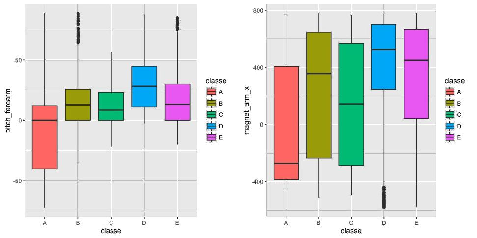

Clearly there is no hard seperation of classes possible using only these ‘highly’ correlated features. Let’s train some models to get closer to a way of predicting these classe’s

Model selection

Let’s identify variables with high correlations amongst each other in our set, so we can possibly exclude them from the pca or training. We will check afterwards if these modifications to the dataset make the model more accurate (and perhaps even faster)

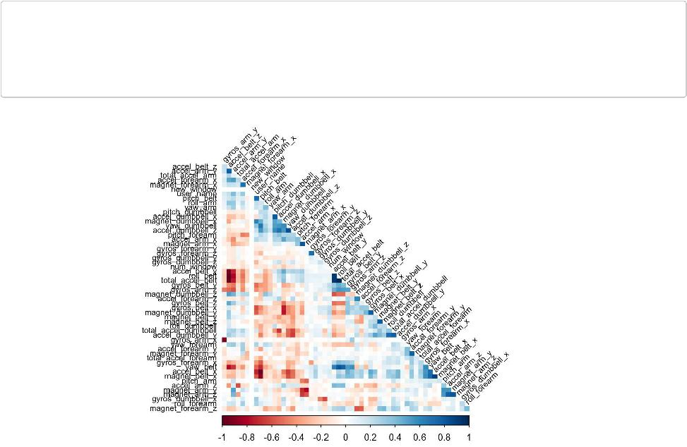

library(corrplot)

correlationMatrix <- cor(training.subSetTrain[, -classeIndex]) highlyCorrelated <- findCorrelation(correlationMatrix, cutoff=0.9, exact=TRUE) excludeColumns <- c(highlyCorrelated, classeIndex)

corrplot(correlationMatrix, method="color", type="lower", order="hclust", tl.cex=0.70, tl.col="black", tl.srt = 4 5, diag = FALSE)

We see that there are some features that aree quite correlated with each other. We will have a model with these excluded. Also we’ll try and reduce the features by running PCA on all and the excluded subset of the features

[figure not shown]

pcaPreProcess.all <- preProcess(training.subSetTrain[, -classeIndex], method = "pca", thresh = 0.99) training.subSetTrain.pca.all <- predict(pcaPreProcess.all, training.subSetTrain[, -classeIndex]) training.subSetTest.pca.all <- predict(pcaPreProcess.all, training.subSetTest[, -classeIndex]) testing.pca.all <- predict(pcaPreProcess.all, testing.cleaned[, -classeIndex])

pcaPreProcess.subset <- preProcess(training.subSetTrain[, -excludeColumns], method = "pca", thresh = 0.99) training.subSetTrain.pca.subset <- predict(pcaPreProcess.subset, training.subSetTrain[, -excludeColumns]) training.subSetTest.pca.subset <- predict(pcaPreProcess.subset, training.subSetTest[, -excludeColumns]) testing.pca.subset <- predict(pcaPreProcess.subset, testing.cleaned[, -classeIndex])

Now we’ll do some actual Random Forest training. We’ll use 200 trees, because I’ve already seen that the error rate doesn’t decline a lot after say 50 trees, but we still want to be thorough. Also we will time each of the 4 random forest models to see if when all else is equal one pops out as the faster one.

library(randomForest)

ntree <- 200 #This is enough for great accuracy (trust me, I'm an engineer).

start <- proc.time() rfMod.cleaned <- randomForest(

x=training.subSetTrain[, -classeIndex], y=training.subSetTrain$classe, xtest=training.subSetTest[, -classeIndex], ytest=training.subSetTest$classe, ntree=ntree,

keep.forest=TRUE, proximity=TRUE) #do.trace=TRUE

proc.time() - start

##usersystem elapsed

##123.6646.228 132.399

[figure not shown]

start <- proc.time() rfMod.exclude <- randomForest(

x=training.subSetTrain[, -excludeColumns], y=training.subSetTrain$classe, xtest=training.subSetTest[, -excludeColumns], ytest=training.subSetTest$classe, ntree=ntree,

keep.forest=TRUE, proximity=TRUE) #do.trace=TRUE

proc.time() - start

##usersystem elapsed

##116.5684.162 121.669

start <- proc.time() rfMod.pca.all <- randomForest(

x=training.subSetTrain.pca.all, y=training.subSetTrain$classe, xtest=training.subSetTest.pca.all, ytest=training.subSetTest$classe, ntree=ntree, keep.forest=TRUE, proximity=TRUE) #do.trace=TRUE

proc.time() - start

##usersystem elapsed

##111.2674.004 115.881

[figure not shown]

start <- proc.time() rfMod.pca.subset <- randomForest(

x=training.subSetTrain.pca.subset, y=training.subSetTrain$classe, xtest=training.subSetTest.pca.subset, ytest=training.subSetTest$classe, ntree=ntree,

keep.forest=TRUE, proximity=TRUE) #do.trace=TRUE

proc.time() - start

##usersystem elapsed

##120.8467.504 138.427

Model examination

Now that we have 4 trained models, we will check the accuracies of each. (There probably is a better way, but this still works good)

rfMod.cleaned

[figure not shown]

| ## |  |  |  |
| --- | --- | --- | --- |
| ## Call: |  |  |  |
| ## | randomForest(x = training.subSetTrain[, -classeIndex], y = training.subSetTrain$classe, |  | xtest = trainin |
| g.subSetTest[, -classeIndex], ytest = training.subSetTest$classe, |  | ntree = ntree, proximity = TRUE, keep.fore |  |
| st = TRUE) |  |  |  |
| ## | Type of random forest: classification |  |  |
| ## | Number of trees: 200 |  |  |

##No. of variables tried at each split: 7

##OOB estimate of error rate: 0.27%

##Confusion matrix:

| ## | A | B | C | D | E class.error |  |
| --- | --- | --- | --- | --- | --- | --- |
| ## A 4185 |  | 0 | 0 | 0 | 0 | 0.000000000 |
| ## B | 7 | 2839 | 2 | 0 | 0 | 0.003160112 |
| ## C | 0 | 8 | 2558 | 1 | 0 | 0.003506038 |
| ## D | 0 | 0 | 16 | 2396 | 0 | 0.006633499 |
| ## E | 0 | 0 | 0 | 6 | 2700 0.002217295 |  |

| ## |  |  |  | Test set error rate: 0.29% |  |  |
| --- | --- | --- | --- | --- | --- | --- |
| ## Confusion matrix: |  |  |  |  |  |  |
| ## | A | B | C | D |  | Eclass.error |
| ## A 1394 |  | 0 | 0 | 0 | 1 | 0.0007168459 |
| ## B | 0 | 949 | 0 | 0 | 0 | 0.0000000000 |
| ## C | 0 | 8 | 847 | 0 | 0 | 0.0093567251 |
| ## D | 0 | 0 | 2 | 801 | 1 | 0.0037313433 |
| ## E | 0 | 0 | 0 | 2 | 899 | 0.0022197558 |

rfMod.cleaned.training.acc <- round(1-sum(rfMod.cleaned$confusion[, 'class.error']),3) paste0("Accuracy on training: ",rfMod.cleaned.training.acc)

## [1] "Accuracy on training: 0.984"

rfMod.cleaned.testing.acc <- round(1-sum(rfMod.cleaned$test$confusion[, 'class.error']),3) paste0("Accuracy on testing: ",rfMod.cleaned.testing.acc)

[figure not shown]

##[1] "Accuracy on testing: 0.984"

rfMod.exclude

| ## |  |  |  |
| --- | --- | --- | --- |
| ## Call: |  |  |  |
| ## | randomForest(x = training.subSetTrain[, -excludeColumns], y = training.subSetTrain$classe, |  | xtest = train |
| ing.subSetTest[, -excludeColumns], ytest = training.subSetTest$classe, |  | ntree = ntree, proximity = TRUE, kee |  |
| p.forest = TRUE) |  |  |  |
| ## | Type of random forest: classification |  |  |
| ## | Number of trees: 200 |  |  |

##No. of variables tried at each split: 7

##OOB estimate of error rate: 0.23%

##Confusion matrix:

| ## | A | B | C | D | E class.error |  |
| --- | --- | --- | --- | --- | --- | --- |
| ## A 4185 |  | 0 | 0 | 0 | 0 | 0.000000000 |
| ## B | 4 | 2842 | 2 | 0 | 0 | 0.002106742 |
| ## C | 0 | 9 | 2558 | 0 | 0 | 0.003506038 |
| ## D | 0 | 0 | 13 | 2398 | 1 | 0.005804312 |
| ## E | 0 | 0 | 0 | 5 | 2701 0.001847746 |  |

| ## |  |  |  | Test set error rate: 0.29% |  |  |
| --- | --- | --- | --- | --- | --- | --- |
| ## Confusion matrix: |  |  |  |  |  |  |
| ## | A | B | C | D |  | Eclass.error |
| ## A 1394 |  | 0 | 0 | 0 | 1 | 0.0007168459 |
| ## B | 1 | 948 | 0 | 0 | 0 | 0.0010537408 |
| ## C | 0 | 8 | 847 | 0 | 0 | 0.0093567251 |
| ## D | 0 | 0 | 0 | 803 | 1 | 0.0012437811 |
| ## E | 0 | 0 | 0 | 3 | 898 | 0.0033296337 |

rfMod.exclude.training.acc <- round(1-sum(rfMod.exclude$confusion[, 'class.error']),3) paste0("Accuracy on training: ",rfMod.exclude.training.acc)

[figure not shown]

## [1] "Accuracy on training: 0.987"

rfMod.exclude.testing.acc <- round(1-sum(rfMod.exclude$test$confusion[, 'class.error']),3) paste0("Accuracy on testing: ",rfMod.exclude.testing.acc)

##[1] "Accuracy on testing: 0.984"

rfMod.pca.all

| ## |  |  |  |
| --- | --- | --- | --- |
| ## Call: |  |  |  |
| ## | randomForest(x = training.subSetTrain.pca.all, y = training.subSetTrain$classe, |  | xtest = training.subSetT |
| est.pca.all, ytest = training.subSetTest$classe, |  | ntree = ntree, proximity = TRUE, keep.forest = TRUE) |  |
| ## | Type of random forest: classification |  |  |
| ## | Number of trees: 200 |  |  |

##No. of variables tried at each split: 6

##OOB estimate of error rate: 2.13%

##Confusion matrix:

| ## | A | B |  | C |  | D | E class.error |  |
| --- | --- | --- | --- | --- | --- | --- | --- | --- |
| ## A 4169 |  | 5 |  | 1 |  | 9 | 1 | 0.003823178 |
| ## B | 57 | 2761 |  | 27 |  | 2 | 1 | 0.030547753 |
| ## C | 2 | 35 | 2505 |  |  | 18 | 7 | 0.024152707 |
| ## D | 2 | 2 |  | 89 | 2311 |  | 8 | 0.041873964 |
| ## E | 4 | 15 |  | 12 |  | 16 | 2659 0.017368810 |  |
| ## |  |  |  | Test set error rate: 1.96% |  |  |  |  |
| ## Confusion matrix: |  |  |  |  |  |  |  |  |
| ## | A | B | C |  | D | E class.error |  |  |
| ## A 1389 |  | 1 | 1 |  | 3 | 1 | 0.004301075 |  |
| ## B | 13 | 922 | 12 |  | 1 | 1 | 0.028451001 |  |
| ## C | 1 | 15 | 833 |  | 5 | 1 | 0.025730994 |  |
| ## D | 2 | 0 | 24 | 775 |  | 3 | 0.036069652 |  |
| ## E | 0 | 4 | 3 |  | 5 | 889 | 0.013318535 |  |

[figure not shown]

rfMod.pca.all.training.acc <- round(1-sum(rfMod.pca.all$confusion[, 'class.error']),3) paste0("Accuracy on training: ",rfMod.pca.all.training.acc)

## [1] "Accuracy on training: 0.882"

rfMod.pca.all.testing.acc <- round(1-sum(rfMod.pca.all$test$confusion[, 'class.error']),3)

paste0("Accuracy on testing: ",rfMod.pca.all.testing.acc)

##[1] "Accuracy on testing: 0.892"

rfMod.pca.subset

[figure not shown]

| ## |  |  |  |
| --- | --- | --- | --- |
| ## Call: |  |  |  |
| ## | randomForest(x = training.subSetTrain.pca.subset, y = training.subSetTrain$classe, |  | xtest = training.subS |
| etTest.pca.subset, ytest = training.subSetTest$classe, |  | ntree = ntree, proximity = TRUE, keep.forest = TRUE) |  |
| ## | Type of random forest: classification |  |  |
| ## | Number of trees: 200 |  |  |

##No. of variables tried at each split: 6

##OOB estimate of error rate: 2.34%

##Confusion matrix:

| ## | A | B |  | C |  | D | E class.error |  |
| --- | --- | --- | --- | --- | --- | --- | --- | --- |
| ## A 4159 |  | 9 |  | 6 |  | 10 | 1 | 0.006212664 |
| ## B | 60 | 2758 |  | 26 |  | 3 | 1 | 0.031601124 |
| ## C | 7 | 31 | 2507 |  |  | 19 | 3 | 0.023373588 |
| ## D | 8 | 1 |  | 97 | 2302 |  | 4 | 0.045605307 |
| ## E | 7 | 16 |  | 20 |  | 15 | 2648 0.021433851 |  |
| ## |  |  |  | Test set error rate: 2.28% |  |  |  |  |
| ## Confusion matrix: |  |  |  |  |  |  |  |  |
| ## | A | B | C |  | D | E class.error |  |  |
| ## A 1382 |  | 5 | 5 |  | 2 | 1 | 0.009318996 |  |
| ## B | 13 | 924 | 11 |  | 0 | 1 | 0.026343519 |  |
| ## C | 2 | 19 | 825 |  | 8 | 1 | 0.035087719 |  |
| ## D | 4 | 0 | 26 | 770 |  | 4 | 0.042288557 |  |
| ## E | 0 | 3 | 0 |  | 7 | 891 | 0.011098779 |  |

rfMod.pca.subset.training.acc <- round(1-sum(rfMod.pca.subset$confusion[, 'class.error']),3) paste0("Accuracy on training: ",rfMod.pca.subset.training.acc)

## [1] "Accuracy on training: 0.872"

rfMod.pca.subset.testing.acc <- round(1-sum(rfMod.pca.subset$test$confusion[, 'class.error']),3) paste0("Accuracy on testing: ",rfMod.pca.subset.testing.acc)

[figure not shown]

## [1] "Accuracy on testing: 0.876"

Conclusion

We’ll stick with the rfMod.exclude model as the best model to use for predicting the test set. Because with an accuracy of 98.7% and an estimated OOB error rate of 0.23% this is the best model.

Before doing the final prediction we will examine the chosen model more in depth using some plots

par(mfrow=c(1,2))

varImpPlot(rfMod.exclude, cex=0.7, pch=16, main='Variable Importance Plot: rfMod.exclude') plot(rfMod.exclude, , cex=0.7, main='Error vs No. of trees plot')

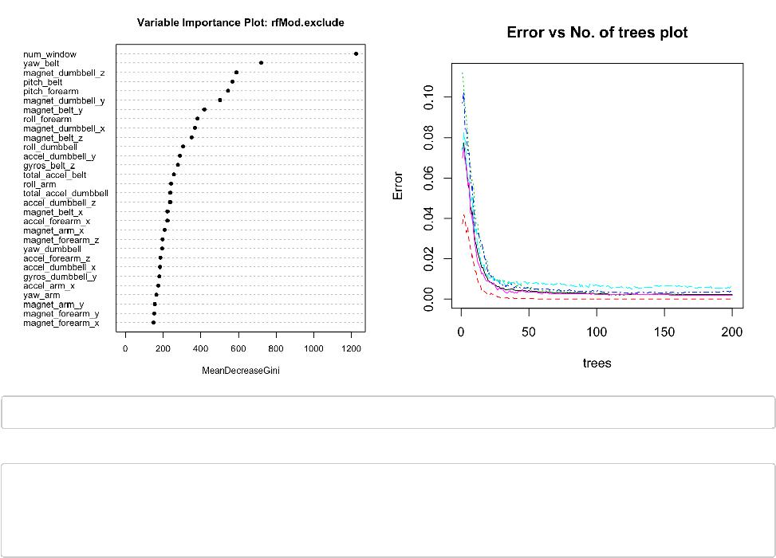

par(mfrow=c(1,1))

To really look in depth at the distances between predictions we can use MDSplot and cluster predictiosn and results

start <- proc.time()

library(RColorBrewer)

palette <- brewer.pal(length(classeLevels), "Set1")

rfMod.mds <- MDSplot(rfMod.exclude, as.factor(classeLevels), k=2, pch=20, palette=palette)

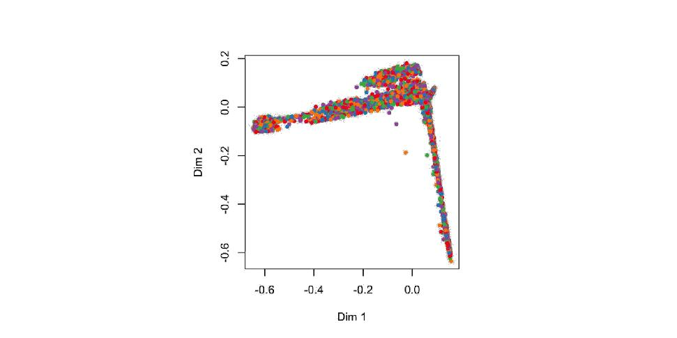

[figure not shown]

library(cluster)

rfMod.pam <- pam(1 - rfMod.exclude$proximity, k=length(classeLevels), diss=TRUE)

plot( rfMod.mds$points[, 1], rfMod.mds$points[, 2], pch=rfMod.pam$clustering+14, col=alpha(palette[as.numeric(training.subSetTrain$classe)],0.5), bg=alpha(palette[as.numeric(training.subSetTrain$classe)],0.2), cex=0.5,

xlab="x", ylab="y")

legend("bottomleft", legend=unique(rfMod.pam$clustering), pch=seq(15,14+length(classeLevels)), title = "PAM clust er")

legend("topleft", legend=classeLevels, pch = 16, col=palette, title = "Classification")

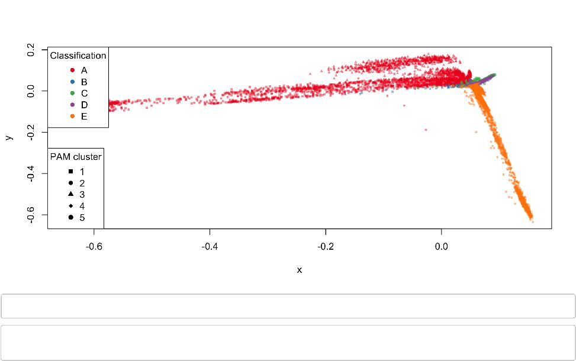

proc.time() - start

##user system elapsed

##4524.813 39.624 4588.622

Test results

[figure not shown]

Although we’ve chosen the rfMod.exclude it’s still nice to see what the other 3 models would predict on the final test set. Let’s look at

predictions for all models on the final test set.

predictions <- t(cbind(

exclude=as.data.frame(predict(rfMod.exclude, testing.cleaned[, -excludeColumns]), optional=TRUE), cleaned=as.data.frame(predict(rfMod.cleaned, testing.cleaned), optional=TRUE), pcaAll=as.data.frame(predict(rfMod.pca.all, testing.pca.all), optional=TRUE), pcaExclude=as.data.frame(predict(rfMod.pca.subset, testing.pca.subset), optional=TRUE)

))

predictions

[output not shown]

## pcaExclude "B" "A" "C" "A" "A" "E" "D" "B" "A" "A" "B" "C" "B" "A" "E" "E" "A" "B" "B" "B"

The predictions don’t really change a lot with each model, but since we have most faith in the rfMod.exclude, we’ll keep that as final answer.